# EDA - Thyroid Classification

# Table of Contents

## Introduction

This notebook performs various exploratory data analysis tasks needed for thyroid classification project.

**Problem Statement**: To build a classification methodology to predict the type of Thyroid a person has, based on the below features.

| Column | Description | Column | Description |
| --- | --- | --- | --- |
| age | Age of the person | TSH_measured | true or false |
| sex | Male or Female | TSH | thyroid stimulating hormone floating value |
| on_thyroxine | true or false | T3_measured | true or false |
| on_antithyroid_medication | true or false | T3 | triiodothyronine value |
| sick | true or false | TT4_measured | true or false |
| pregnant | true or false | TT4 | Thyroxine value |
| thyroid_surgery | true or false | T4U_measured | true or false |
| I131_treatment | true or false | T4U | numerical value |
| query_hypothyroid | true or false | FTI_measured | true or false |
| query_hyperthyroid | true or false | FTI | Free Thyroxine Index |
| lithium | true or false | TBG_measured | true or false |
| goitre | true or false | TBG | Thyroid Binding Globulin value |
| tumor | true or false | referral_source | different sources of referals |
| hypopituitary | true or false | Class | different types of thyroid |
| psych | true or false |  |  |

```python
# General imports
import pandas as pd
import numpy as np
import matplotlib.pyplot as plt
%matplotlib inline
import seaborn as sns
from sklearn.preprocessing import LabelEncoder
from sklearn.impute import KNNImputer
from scipy import stats
from imblearn.over_sampling import RandomOverSampler
from sklearn.cluster import KMeans

pd.set_option('display.max_rows', 500)
pd.set_option('display.max_columns', 500)
pd.set_option('display.width', 1000)
```

## Read the data

```python
# Read clean data exported from DB
df = pd.read_csv('Training/TrainingFile_FromDB/InputFile.csv')
df.shape
```

```
(3972, 30)
```

> Data exported from database has 3972 records and 30 columns.

```python
# Check head
df.head(10)
```

|  | age | sex | on_thyroxine | query_on_thyroxine | on_antithyroid_medication | sick | pregnant | thyroid_surgery | I131_treatment | query_hypothyroid | query_hyperthyroid | lithium | goitre | tumor | hypopituitary | psych | TSH_measured | TSH | T3_measured | T3 | TT4_measured | TT4 | T4U_measured | T4U | FTI_measured | FTI | TBG_measured | TBG | referral_source | … |
| --- | --- | --- | --- | --- | --- | --- | --- | --- | --- | --- | --- | --- | --- | --- | --- | --- | --- | --- | --- | --- | --- | --- | --- | --- | --- | --- | --- | --- | --- | --- |
| 0 | 49 | F | f | f | f | t | f | f | f | f | f | f | f | f | f | f | t | 1.0 | t | 1.6 | t | 93.0 | t | 0.94 | t | 99.0 | f | ? | other | … |
| 1 | 46 | M | f | f | f | f | f | f | f | f | f | f | f | f | f | t | t | 1.1 | t | 2.9 | t | 125.0 | t | 1.02 | t | 122.0 | f | ? | SVHC | … |
| 2 | 80 | F | f | f | t | f | f | f | f | f | f | f | f | f | f | f | t | 2.2 | t | 1.7 | t | 83.0 | t | 1.11 | t | 76.0 | f | ? | other | … |
| 3 | 80 | F | f | f | f | f | f | f | f | f | f | f | f | f | f | t | t | 1.1 | t | 1.8 | t | 94.0 | t | 0.94 | t | 100.0 | f | ? | SVHC | … |
| 4 | 26 | F | f | f | f | f | f | f | f | f | f | f | f | f | f | f | f | ? | f | ? | f | ? | f | ? | f | ? | f | ? | other | … |
| 5 | 68 | M | f | f | f | f | f | f | f | f | f | f | f | f | f | f | t | 1.9 | t | 2.9 | t | 90.0 | t | 1.0 | t | 90.0 | f | ? | SVI | … |
| 6 | 24 | M | f | f | f | f | f | f | f | f | f | f | f | f | f | f | t | 0.6 | t | 3.0 | t | 119.0 | t | 1.03 | t | 115.0 | f | ? | other | … |
| 7 | 21 | F | f | f | f | f | f | f | f | f | t | f | f | f | f | f | f | ? | f | ? | f | ? | f | ? | f | ? | f | ? | other | … |
| 8 | 38 | M | f | f | f | f | f | f | f | f | f | f | f | f | f | f | f | ? | f | ? | t | 78.0 | t | 0.87 | t | 90.0 | f | ? | other | … |
| 9 | 55 | F | t | f | f | f | f | f | f | f | f | f | f | f | f | f | t | 0.05 | t | 2.8 | t | 189.0 | t | 1.66 | t | 114.0 | f | ? | other | … |

> Observations:

> ```
> - The data does not show any missing values. However, looking closely, we can see that missing values are indicated by `?`.<br>
> - Some columns such as `FTI_measured` with t/f values are just indicating whether the next column `FTI` has a value or not.
> ```

Let's count the number of missing and remove additional columns that do not add any value.

## Data Exploration

### Missing Values

#### Identify missing

```python
# Define function to count missing values represented by '?'
def calc_missing(df):
    print(f'Column \t No. of missing')
    for col in df.columns:
        count = df[col][df[col]=='?'].count()
        if count != 0:
            print(f'{col} \t {count}')
```

```python
# Count missing
calc_missing(df)
```

```
Column 	 No. of missing
age 	 1
sex 	 157
TSH 	 390
T3 	 812
TT4 	 247
T4U 	 409
FTI 	 407
TBG 	 3972
```

> All records in the TBG column are missing. We will drop this column later.

#### Replace `?` with `Nan`

```python
# Define function
def replace_missing(df):
    for col in df.columns:
        count = df[col][df[col]=='?'].count()
        if count != 0:
            df[col] = df[col].replace('?', np.nan)
```

```python
# Replace ? with Nan
replace_missing(df)
```

```python
# Check missing
df.isnull().sum()
```

```
age                             1
sex                           157
on_thyroxine                    0
query_on_thyroxine              0
on_antithyroid_medication       0
sick                            0
pregnant                        0
thyroid_surgery                 0
I131_treatment                  0
query_hypothyroid               0
query_hyperthyroid              0
lithium                         0
goitre                          0
tumor                           0
hypopituitary                   0
psych                           0
TSH_measured                    0
TSH                           390
T3_measured                     0
T3                            812
TT4_measured                    0
TT4                           247
T4U_measured                    0
T4U                           409
FTI_measured                    0
FTI                           407
TBG_measured                    0
TBG                          3972
referral_source                 0
Class                           0
dtype: int64
```

### Remove columns with duplicate information

Columns with `_measured` in the column name contain t/f values which are just indicators of whether the next column FTI has a value or not. Since these columns do not add any information to the data, we will remove these columns.

```python
# Look at columns with duplicate information
df.iloc[:, -13:-2].head()
```

|  | TSH | T3_measured | T3 | TT4_measured | TT4 | T4U_measured | T4U | FTI_measured | FTI | TBG_measured | TBG |
| --- | --- | --- | --- | --- | --- | --- | --- | --- | --- | --- | --- |
| 0 | 1.0 | t | 1.6 | t | 93.0 | t | 0.94 | t | 99.0 | f | NaN |
| 1 | 1.1 | t | 2.9 | t | 125.0 | t | 1.02 | t | 122.0 | f | NaN |
| 2 | 2.2 | t | 1.7 | t | 83.0 | t | 1.11 | t | 76.0 | f | NaN |
| 3 | 1.1 | t | 1.8 | t | 94.0 | t | 0.94 | t | 100.0 | f | NaN |
| 4 | NaN | f | NaN | f | NaN | f | NaN | f | NaN | f | NaN |

> `t` in a column with `_measured` indicates that the next column has a value and `f` indicates a missing value in the next column.

We will drop the columns with `_measured`.

```python
# Identify columns
cols_to_drop = [col for col in df.columns if '_measured' in col]
cols_to_drop
```

```
['TSH_measured',
 'T3_measured',
 'TT4_measured',
 'T4U_measured',
 'FTI_measured',
 'TBG_measured']
```

```python
df['TBG'].isna().sum()
```

```
3972
```

```python
# Identify columns that do not have any variation in data as they do not add any value
for col in df.columns:
    if df[col].isna().sum() == df.shape[0]:
        cols_to_drop.append(col)
```

```python
cols_to_drop
```

```
['TSH_measured',
 'T3_measured',
 'TT4_measured',
 'T4U_measured',
 'FTI_measured',
 'TBG_measured',
 'TBG']
```

```python
# Drop columns
df.drop(columns=cols_to_drop, axis=1, inplace=True)
df.shape
```

```
(3972, 23)
```

```python
# Check data
df.describe()
```

|  | age | sex | on_thyroxine | query_on_thyroxine | on_antithyroid_medication | sick | pregnant | thyroid_surgery | I131_treatment | query_hypothyroid | query_hyperthyroid | lithium | goitre | tumor | hypopituitary | psych | TSH | T3 | TT4 | T4U | FTI | referral_source | Class |
| --- | --- | --- | --- | --- | --- | --- | --- | --- | --- | --- | --- | --- | --- | --- | --- | --- | --- | --- | --- | --- | --- | --- | --- |
| count | 3971 | 3815 | 3972 | 3972 | 3972 | 3972 | 3972 | 3972 | 3972 | 3972 | 3972 | 3972 | 3972 | 3972 | 3972 | 3972 | 3582 | 3160 | 3725 | 3563 | 3565 | 3972 | 3972 |
| unique | 93 | 2 | 2 | 2 | 2 | 2 | 2 | 2 | 2 | 2 | 2 | 2 | 2 | 2 | 2 | 2 | 287 | 69 | 241 | 146 | 234 | 5 | 4 |
| top | 59 | F | f | f | f | f | f | f | f | f | f | f | f | f | f | f | 0.2 | 2.0 | 101.0 | 0.99 | 100.0 | other | negative |
| freq | 102 | 2608 | 3484 | 3916 | 3926 | 3816 | 3917 | 3917 | 3906 | 3733 | 3726 | 3952 | 3937 | 3872 | 3971 | 3780 | 119 | 251 | 72 | 101 | 77 | 2317 | 3668 |

> Observation:

> ```
> - Majority of the data is categorical with two categories.
> - Referral source column has 5 and the Class column has 4 categories.
> ```

Before we impute the missing data, let's map the binary categories and encode the multi-categories to nurical data as needed.

### Feature Engineering

In this section, we will map the features with binary categories and encode the features with multi-categories to numerical data.

#### Convert `sex` column to numerical

```python
# Check data type and categories
print(df['sex'].dtype)
print(df['sex'].value_counts())
```

```
object
F    2608
M    1207
Name: sex, dtype: int64
```

```python
# Convert to numerical
df['sex'] = df['sex'].map({'F':0, 'M':1})
```

```python
# Check data type
df['sex'].dtype
```

```
dtype('float64')
```

#### Convert columns with binary categories to numerical

There are many columns with two unqiue `t` and `f` categories. Let's map these to numerical 0 and 1.

```python
for col in df.columns:
    print(f'{col} \t {len(df[col].unique())}')
```

```
age 	 94
sex 	 3
on_thyroxine 	 2
query_on_thyroxine 	 2
on_antithyroid_medication 	 2
sick 	 2
pregnant 	 2
thyroid_surgery 	 2
I131_treatment 	 2
query_hypothyroid 	 2
query_hyperthyroid 	 2
lithium 	 2
goitre 	 2
tumor 	 2
hypopituitary 	 2
psych 	 2
TSH 	 288
T3 	 70
TT4 	 242
T4U 	 147
FTI 	 235
referral_source 	 5
Class 	 4
```

```python
# Map categories
for col in df.columns:
    if len(df[col].unique())==2:
        df[col] = df[col].map({'f':0, 't':1})
```

```python
# Check head
df.head()
```

|  | age | sex | on_thyroxine | query_on_thyroxine | on_antithyroid_medication | sick | pregnant | thyroid_surgery | I131_treatment | query_hypothyroid | query_hyperthyroid | lithium | goitre | tumor | hypopituitary | psych | TSH | T3 | TT4 | T4U | FTI | referral_source | Class |
| --- | --- | --- | --- | --- | --- | --- | --- | --- | --- | --- | --- | --- | --- | --- | --- | --- | --- | --- | --- | --- | --- | --- | --- |
| 0 | 49 | 0.0 | 0 | 0 | 0 | 1 | 0 | 0 | 0 | 0 | 0 | 0 | 0 | 0 | 0 | 0 | 1.0 | 1.6 | 93.0 | 0.94 | 99.0 | other | negative |
| 1 | 46 | 1.0 | 0 | 0 | 0 | 0 | 0 | 0 | 0 | 0 | 0 | 0 | 0 | 0 | 0 | 1 | 1.1 | 2.9 | 125.0 | 1.02 | 122.0 | SVHC | negative |
| 2 | 80 | 0.0 | 0 | 0 | 1 | 0 | 0 | 0 | 0 | 0 | 0 | 0 | 0 | 0 | 0 | 0 | 2.2 | 1.7 | 83.0 | 1.11 | 76.0 | other | negative |
| 3 | 80 | 0.0 | 0 | 0 | 0 | 0 | 0 | 0 | 0 | 0 | 0 | 0 | 0 | 0 | 0 | 1 | 1.1 | 1.8 | 94.0 | 0.94 | 100.0 | SVHC | negative |
| 4 | 26 | 0.0 | 0 | 0 | 0 | 0 | 0 | 0 | 0 | 0 | 0 | 0 | 0 | 0 | 0 | 0 | NaN | NaN | NaN | NaN | NaN | other | negative |

#### One-Hot encode `referral source`

The column has multiple categories. Let's create dummy variables for these categories

```python
# Check categories
df['referral_source'].unique()
```

```
array(['other', 'SVHC', 'SVI', 'STMW', 'SVHD'], dtype=object)
```

```python
# Create dummy variables
# drop_first=True to avoid dummy variable trap
df = pd.get_dummies(data=df, columns=['referral_source'], drop_first=True)
```

```python
# Check head
df.head(2)
```

|  | age | sex | on_thyroxine | query_on_thyroxine | on_antithyroid_medication | sick | pregnant | thyroid_surgery | I131_treatment | query_hypothyroid | query_hyperthyroid | lithium | goitre | tumor | hypopituitary | psych | TSH | T3 | TT4 | T4U | FTI | Class | referral_source_SVHC | referral_source_SVHD | referral_source_SVI | referral_source_other |
| --- | --- | --- | --- | --- | --- | --- | --- | --- | --- | --- | --- | --- | --- | --- | --- | --- | --- | --- | --- | --- | --- | --- | --- | --- | --- | --- |
| 0 | 49 | 0.0 | 0 | 0 | 0 | 1 | 0 | 0 | 0 | 0 | 0 | 0 | 0 | 0 | 0 | 0 | 1.0 | 1.6 | 93.0 | 0.94 | 99.0 | negative | 0 | 0 | 0 | 1 |
| 1 | 46 | 1.0 | 0 | 0 | 0 | 0 | 0 | 0 | 0 | 0 | 0 | 0 | 0 | 0 | 0 | 1 | 1.1 | 2.9 | 125.0 | 1.02 | 122.0 | negative | 1 | 0 | 0 | 0 |

#### Label encode `Class`

The coulmn has multiple categories. Since `Class` represents various severities of thyroid, we will label encode the feature.

```python
# Check categories
df['Class'].unique()
```

```
array(['negative', 'compensated_hypothyroid', 'primary_hypothyroid',
       'secondary_hypothyroid'], dtype=object)
```

```python
# Encode
encoder = LabelEncoder()
df['Class'] = encoder.fit_transform(df['Class'])
```

```python
# Check categories
df['Class'].unique()
```

```
array([1, 0, 2, 3])
```

### Impute Missing

The data has a lot of missing values and we will use `KNNImputer` to impute the missing.

```python
# Check missing
df.isnull().sum()
```

```
age                            1
sex                          157
on_thyroxine                   0
query_on_thyroxine             0
on_antithyroid_medication      0
sick                           0
pregnant                       0
thyroid_surgery                0
I131_treatment                 0
query_hypothyroid              0
query_hyperthyroid             0
lithium                        0
goitre                         0
tumor                          0
hypopituitary                  0
psych                          0
TSH                          390
T3                           812
TT4                          247
T4U                          409
FTI                          407
Class                          0
referral_source_SVHC           0
referral_source_SVHD           0
referral_source_SVI            0
referral_source_other          0
dtype: int64
```

```python
# Impute data
imputer = KNNImputer(n_neighbors=3, weights='uniform', missing_values=np.nan)
new_array = imputer.fit_transform(df)
```

```python
# Convert array to df
new_df = pd.DataFrame(np.round(new_array), columns=df.columns)
new_df.head()
```

|  | age | sex | on_thyroxine | query_on_thyroxine | on_antithyroid_medication | sick | pregnant | thyroid_surgery | I131_treatment | query_hypothyroid | query_hyperthyroid | lithium | goitre | tumor | hypopituitary | psych | TSH | T3 | TT4 | T4U | FTI | Class | referral_source_SVHC | referral_source_SVHD | referral_source_SVI | referral_source_other |
| --- | --- | --- | --- | --- | --- | --- | --- | --- | --- | --- | --- | --- | --- | --- | --- | --- | --- | --- | --- | --- | --- | --- | --- | --- | --- | --- |
| 0 | 49.0 | 0.0 | 0.0 | 0.0 | 0.0 | 1.0 | 0.0 | 0.0 | 0.0 | 0.0 | 0.0 | 0.0 | 0.0 | 0.0 | 0.0 | 0.0 | 1.0 | 2.0 | 93.0 | 1.0 | 99.0 | 1.0 | 0.0 | 0.0 | 0.0 | 1.0 |
| 1 | 46.0 | 1.0 | 0.0 | 0.0 | 0.0 | 0.0 | 0.0 | 0.0 | 0.0 | 0.0 | 0.0 | 0.0 | 0.0 | 0.0 | 0.0 | 1.0 | 1.0 | 3.0 | 125.0 | 1.0 | 122.0 | 1.0 | 1.0 | 0.0 | 0.0 | 0.0 |
| 2 | 80.0 | 0.0 | 0.0 | 0.0 | 1.0 | 0.0 | 0.0 | 0.0 | 0.0 | 0.0 | 0.0 | 0.0 | 0.0 | 0.0 | 0.0 | 0.0 | 2.0 | 2.0 | 83.0 | 1.0 | 76.0 | 1.0 | 0.0 | 0.0 | 0.0 | 1.0 |
| 3 | 80.0 | 0.0 | 0.0 | 0.0 | 0.0 | 0.0 | 0.0 | 0.0 | 0.0 | 0.0 | 0.0 | 0.0 | 0.0 | 0.0 | 0.0 | 1.0 | 1.0 | 2.0 | 94.0 | 1.0 | 100.0 | 1.0 | 1.0 | 0.0 | 0.0 | 0.0 |
| 4 | 26.0 | 0.0 | 0.0 | 0.0 | 0.0 | 0.0 | 0.0 | 0.0 | 0.0 | 0.0 | 0.0 | 0.0 | 0.0 | 0.0 | 0.0 | 0.0 | 2.0 | 3.0 | 108.0 | 1.0 | 90.0 | 1.0 | 0.0 | 0.0 | 0.0 | 1.0 |

```python
# Check missing
new_df.isnull().sum()
```

```
age                          0
sex                          0
on_thyroxine                 0
query_on_thyroxine           0
on_antithyroid_medication    0
sick                         0
pregnant                     0
thyroid_surgery              0
I131_treatment               0
query_hypothyroid            0
query_hyperthyroid           0
lithium                      0
goitre                       0
tumor                        0
hypopituitary                0
psych                        0
TSH                          0
T3                           0
TT4                          0
T4U                          0
FTI                          0
Class                        0
referral_source_SVHC         0
referral_source_SVHD         0
referral_source_SVI          0
referral_source_other        0
dtype: int64
```

```python
# Check data
new_df.describe()
```

|  | age | sex | on_thyroxine | query_on_thyroxine | on_antithyroid_medication | sick | pregnant | thyroid_surgery | I131_treatment | query_hypothyroid | query_hyperthyroid | lithium | goitre | tumor | hypopituitary | psych | TSH | T3 | TT4 | T4U | FTI | Class | referral_source_SVHC | referral_source_SVHD | referral_source_SVI | referral_source_other |
| --- | --- | --- | --- | --- | --- | --- | --- | --- | --- | --- | --- | --- | --- | --- | --- | --- | --- | --- | --- | --- | --- | --- | --- | --- | --- | --- |
| count | 3972.000000 | 3972.000000 | 3972.000000 | 3972.000000 | 3972.000000 | 3972.000000 | 3972.000000 | 3972.000000 | 3972.000000 | 3972.000000 | 3972.000000 | 3972.000000 | 3972.000000 | 3972.000000 | 3972.000000 | 3972.000000 | 3972.000000 | 3972.000000 | 3972.000000 | 3972.000000 | 3972.000000 | 3972.000000 | 3972.000000 | 3972.000000 | 3972.000000 | 3972.000000 |
| mean | 51.681017 | 0.309416 | 0.122860 | 0.014099 | 0.011581 | 0.039275 | 0.013847 | 0.013847 | 0.016616 | 0.060171 | 0.061934 | 0.005035 | 0.008812 | 0.025176 | 0.000252 | 0.048338 | 4.816717 | 2.035247 | 108.469789 | 1.020393 | 110.100453 | 0.974824 | 0.103474 | 0.010070 | 0.273414 | 0.583333 |
| std | 21.079318 | 0.462311 | 0.328318 | 0.117913 | 0.107004 | 0.194273 | 0.116870 | 0.116870 | 0.127845 | 0.237834 | 0.241065 | 0.070790 | 0.093468 | 0.156680 | 0.015867 | 0.214507 | 23.011349 | 0.780502 | 34.717478 | 0.162878 | 31.999075 | 0.278266 | 0.304616 | 0.099858 | 0.445768 | 0.493069 |
| min | 1.000000 | 0.000000 | 0.000000 | 0.000000 | 0.000000 | 0.000000 | 0.000000 | 0.000000 | 0.000000 | 0.000000 | 0.000000 | 0.000000 | 0.000000 | 0.000000 | 0.000000 | 0.000000 | 0.000000 | 0.000000 | 2.000000 | 0.000000 | 2.000000 | 0.000000 | 0.000000 | 0.000000 | 0.000000 | 0.000000 |
| 25% | 36.000000 | 0.000000 | 0.000000 | 0.000000 | 0.000000 | 0.000000 | 0.000000 | 0.000000 | 0.000000 | 0.000000 | 0.000000 | 0.000000 | 0.000000 | 0.000000 | 0.000000 | 0.000000 | 1.000000 | 2.000000 | 88.000000 | 1.000000 | 93.000000 | 1.000000 | 0.000000 | 0.000000 | 0.000000 | 0.000000 |
| 50% | 54.000000 | 0.000000 | 0.000000 | 0.000000 | 0.000000 | 0.000000 | 0.000000 | 0.000000 | 0.000000 | 0.000000 | 0.000000 | 0.000000 | 0.000000 | 0.000000 | 0.000000 | 0.000000 | 1.000000 | 2.000000 | 104.000000 | 1.000000 | 107.000000 | 1.000000 | 0.000000 | 0.000000 | 0.000000 | 1.000000 |
| 75% | 67.000000 | 1.000000 | 0.000000 | 0.000000 | 0.000000 | 0.000000 | 0.000000 | 0.000000 | 0.000000 | 0.000000 | 0.000000 | 0.000000 | 0.000000 | 0.000000 | 0.000000 | 0.000000 | 3.000000 | 2.000000 | 124.000000 | 1.000000 | 124.000000 | 1.000000 | 0.000000 | 0.000000 | 1.000000 | 1.000000 |
| max | 455.000000 | 1.000000 | 1.000000 | 1.000000 | 1.000000 | 1.000000 | 1.000000 | 1.000000 | 1.000000 | 1.000000 | 1.000000 | 1.000000 | 1.000000 | 1.000000 | 1.000000 | 1.000000 | 530.000000 | 11.000000 | 430.000000 | 2.000000 | 395.000000 | 3.000000 | 1.000000 | 1.000000 | 1.000000 | 1.000000 |

### Handle Outliers

Let's check the distribution of some numeric features.

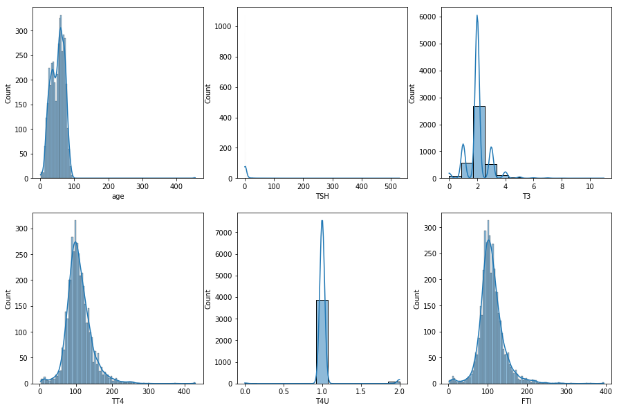

```python
# Create histograms
cols = ['age','TSH','T3','TT4','T4U','FTI']

plt.figure(figsize=(15,10),facecolor='white')
plotnumber = 1

for col in cols:
    ax = plt.subplot(2,3,plotnumber)
    sns.histplot(new_df[col], kde=True, ax=ax)
#     sns.boxplot(x=new_df[col], ax=ax)
    plt.xlabel(col, fontsize=10)
    plotnumber+=1
```

> Observation:

> ```
> - The distributions of some features look skewed which could be due to the presence of outliers.
> ```

Let's create box-plots to determine outliers.

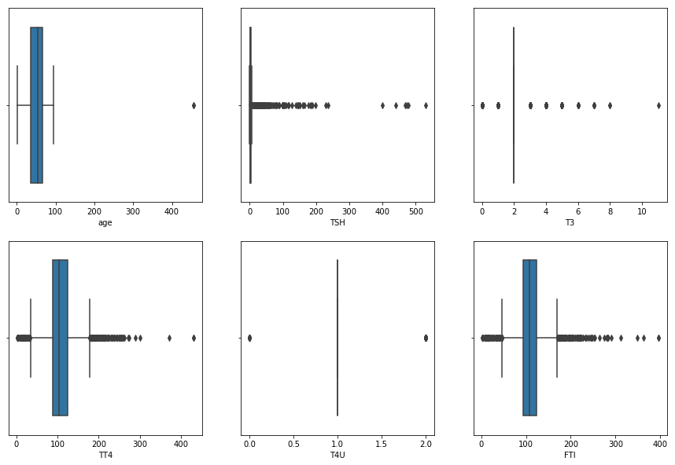

```python
# Create boxplots
cols = ['age','TSH','T3','TT4','T4U','FTI']

plt.figure(figsize=(15,10),facecolor='white')
plotnumber = 1

for col in cols:
    ax = plt.subplot(2,3,plotnumber)
    sns.boxplot(x=new_df[col])
    plt.xlabel(col, fontsize=10)
    plotnumber+=1
```

> Observations:

> ```
> - Box plots show outliers in most features.
> - Age cannot be > 400, so we will remove the record.
> - TSH normally range from 0.1-15 however there is no upper limit. A quick google search shows that most labs can measure TSH upto 150 mlU/ml. We will remove records will TSH > 150.
> ```

#### Remove recrods with `age > 100` and `TSH > 150`

```python
# Recrods with age > 100
len(new_df[new_df['age']>100])
```

```
2
```

```python
# Recrods with TSH > 150
len(new_df[new_df['TSH']>150]['TSH'])
```

```
19
```

```python
len(new_df[new_df['age']>100])
```

```
2
```

```python
new_df[(new_df['age']>100) | (new_df['TSH']>150)]
```

|  | age | sex | on_thyroxine | query_on_thyroxine | on_antithyroid_medication | sick | pregnant | thyroid_surgery | I131_treatment | query_hypothyroid | query_hyperthyroid | lithium | goitre | tumor | hypopituitary | psych | TSH | T3 | TT4 | T4U | FTI | Class | referral_source_SVHC | referral_source_SVHD | referral_source_SVI | referral_source_other |
| --- | --- | --- | --- | --- | --- | --- | --- | --- | --- | --- | --- | --- | --- | --- | --- | --- | --- | --- | --- | --- | --- | --- | --- | --- | --- | --- |
| 288 | 39.0 | 0.0 | 0.0 | 0.0 | 0.0 | 0.0 | 0.0 | 0.0 | 0.0 | 0.0 | 0.0 | 0.0 | 0.0 | 0.0 | 0.0 | 0.0 | 160.0 | 0.0 | 11.0 | 1.0 | 9.0 | 2.0 | 0.0 | 0.0 | 0.0 | 1.0 |
| 316 | 50.0 | 1.0 | 0.0 | 0.0 | 0.0 | 0.0 | 0.0 | 0.0 | 0.0 | 0.0 | 0.0 | 0.0 | 0.0 | 0.0 | 0.0 | 0.0 | 151.0 | 1.0 | 32.0 | 1.0 | 28.0 | 2.0 | 0.0 | 0.0 | 0.0 | 1.0 |
| 639 | 33.0 | 1.0 | 0.0 | 0.0 | 0.0 | 0.0 | 0.0 | 0.0 | 0.0 | 0.0 | 0.0 | 0.0 | 0.0 | 0.0 | 0.0 | 0.0 | 160.0 | 0.0 | 10.0 | 1.0 | 13.0 | 2.0 | 0.0 | 0.0 | 1.0 | 0.0 |
| 937 | 53.0 | 0.0 | 0.0 | 0.0 | 0.0 | 0.0 | 0.0 | 0.0 | 0.0 | 0.0 | 0.0 | 0.0 | 0.0 | 0.0 | 0.0 | 0.0 | 165.0 | 0.0 | 17.0 | 1.0 | 14.0 | 2.0 | 0.0 | 0.0 | 0.0 | 1.0 |
| 1018 | 60.0 | 0.0 | 0.0 | 0.0 | 0.0 | 0.0 | 0.0 | 0.0 | 0.0 | 0.0 | 0.0 | 0.0 | 0.0 | 0.0 | 0.0 | 0.0 | 151.0 | 1.0 | 42.0 | 1.0 | 39.0 | 2.0 | 0.0 | 0.0 | 0.0 | 1.0 |
| 1307 | 2.0 | 0.0 | 0.0 | 0.0 | 0.0 | 0.0 | 0.0 | 0.0 | 0.0 | 0.0 | 0.0 | 0.0 | 0.0 | 0.0 | 0.0 | 0.0 | 472.0 | 2.0 | 34.0 | 1.0 | 29.0 | 2.0 | 0.0 | 0.0 | 0.0 | 0.0 |
| 1564 | 455.0 | 0.0 | 0.0 | 0.0 | 0.0 | 0.0 | 0.0 | 0.0 | 0.0 | 0.0 | 0.0 | 0.0 | 0.0 | 0.0 | 0.0 | 0.0 | 1.0 | 2.0 | 118.0 | 1.0 | 104.0 | 1.0 | 0.0 | 0.0 | 1.0 | 0.0 |
| 1575 | 53.0 | 0.0 | 0.0 | 0.0 | 0.0 | 0.0 | 0.0 | 0.0 | 0.0 | 0.0 | 0.0 | 0.0 | 0.0 | 0.0 | 0.0 | 0.0 | 183.0 | 1.0 | 14.0 | 1.0 | 11.0 | 2.0 | 0.0 | 0.0 | 0.0 | 1.0 |
| 1902 | 60.0 | 0.0 | 0.0 | 0.0 | 0.0 | 0.0 | 0.0 | 0.0 | 0.0 | 1.0 | 0.0 | 0.0 | 0.0 | 0.0 | 0.0 | 0.0 | 183.0 | 1.0 | 45.0 | 1.0 | 46.0 | 2.0 | 0.0 | 0.0 | 0.0 | 1.0 |
| 1972 | 25.0 | 0.0 | 0.0 | 0.0 | 0.0 | 0.0 | 0.0 | 0.0 | 0.0 | 0.0 | 0.0 | 0.0 | 0.0 | 0.0 | 0.0 | 0.0 | 468.0 | 1.0 | 21.0 | 1.0 | 19.0 | 2.0 | 0.0 | 0.0 | 0.0 | 1.0 |
| 2027 | 18.0 | 0.0 | 0.0 | 0.0 | 0.0 | 0.0 | 0.0 | 0.0 | 0.0 | 0.0 | 0.0 | 0.0 | 0.0 | 0.0 | 0.0 | 0.0 | 440.0 | 0.0 | 24.0 | 1.0 | 18.0 | 2.0 | 0.0 | 0.0 | 0.0 | 1.0 |
| 2049 | 59.0 | 0.0 | 0.0 | 0.0 | 0.0 | 0.0 | 0.0 | 0.0 | 0.0 | 0.0 | 0.0 | 0.0 | 0.0 | 0.0 | 0.0 | 0.0 | 530.0 | 2.0 | 10.0 | 1.0 | 8.0 | 2.0 | 0.0 | 0.0 | 0.0 | 1.0 |
| 2239 | 44.0 | 1.0 | 0.0 | 0.0 | 0.0 | 0.0 | 0.0 | 0.0 | 0.0 | 0.0 | 0.0 | 0.0 | 0.0 | 0.0 | 0.0 | 0.0 | 199.0 | 1.0 | 10.0 | 1.0 | 10.0 | 2.0 | 0.0 | 0.0 | 1.0 | 0.0 |
| 2259 | 31.0 | 0.0 | 0.0 | 0.0 | 0.0 | 0.0 | 0.0 | 0.0 | 0.0 | 0.0 | 0.0 | 0.0 | 0.0 | 0.0 | 0.0 | 0.0 | 188.0 | 1.0 | 63.0 | 1.0 | 53.0 | 2.0 | 0.0 | 0.0 | 0.0 | 1.0 |
| 2777 | 25.0 | 1.0 | 0.0 | 0.0 | 0.0 | 0.0 | 0.0 | 0.0 | 0.0 | 0.0 | 0.0 | 0.0 | 0.0 | 0.0 | 0.0 | 0.0 | 236.0 | 0.0 | 16.0 | 1.0 | 17.0 | 2.0 | 0.0 | 0.0 | 0.0 | 1.0 |
| 3039 | 60.0 | 0.0 | 1.0 | 0.0 | 0.0 | 0.0 | 0.0 | 0.0 | 0.0 | 0.0 | 0.0 | 0.0 | 0.0 | 0.0 | 0.0 | 0.0 | 400.0 | 0.0 | 11.0 | 1.0 | 9.0 | 2.0 | 0.0 | 0.0 | 0.0 | 1.0 |
| 3054 | 35.0 | 0.0 | 0.0 | 0.0 | 0.0 | 0.0 | 0.0 | 0.0 | 0.0 | 0.0 | 1.0 | 0.0 | 0.0 | 0.0 | 0.0 | 0.0 | 230.0 | 2.0 | 36.0 | 1.0 | 27.0 | 2.0 | 0.0 | 0.0 | 0.0 | 1.0 |
| 3337 | 18.0 | 0.0 | 1.0 | 0.0 | 0.0 | 0.0 | 0.0 | 0.0 | 0.0 | 0.0 | 0.0 | 0.0 | 0.0 | 0.0 | 0.0 | 0.0 | 478.0 | 3.0 | 45.0 | 1.0 | 34.0 | 2.0 | 0.0 | 0.0 | 0.0 | 1.0 |
| 3736 | 455.0 | 0.0 | 0.0 | 0.0 | 0.0 | 0.0 | 0.0 | 0.0 | 0.0 | 0.0 | 0.0 | 0.0 | 0.0 | 0.0 | 0.0 | 0.0 | 1.0 | 2.0 | 118.0 | 1.0 | 104.0 | 1.0 | 0.0 | 0.0 | 1.0 | 0.0 |
| 3747 | 53.0 | 0.0 | 0.0 | 0.0 | 0.0 | 0.0 | 0.0 | 0.0 | 0.0 | 0.0 | 0.0 | 0.0 | 0.0 | 0.0 | 0.0 | 0.0 | 183.0 | 1.0 | 14.0 | 1.0 | 11.0 | 2.0 | 0.0 | 0.0 | 0.0 | 1.0 |
| 3787 | 48.0 | 0.0 | 1.0 | 0.0 | 0.0 | 0.0 | 0.0 | 0.0 | 0.0 | 1.0 | 0.0 | 0.0 | 0.0 | 0.0 | 0.0 | 0.0 | 178.0 | 1.0 | 63.0 | 1.0 | 59.0 | 2.0 | 0.0 | 0.0 | 0.0 | 1.0 |

```python
# Subset data
df2 = new_df[(new_df['age']<=100) & (new_df['TSH']<=150)]
df2.shape
```

```
(3951, 26)
```

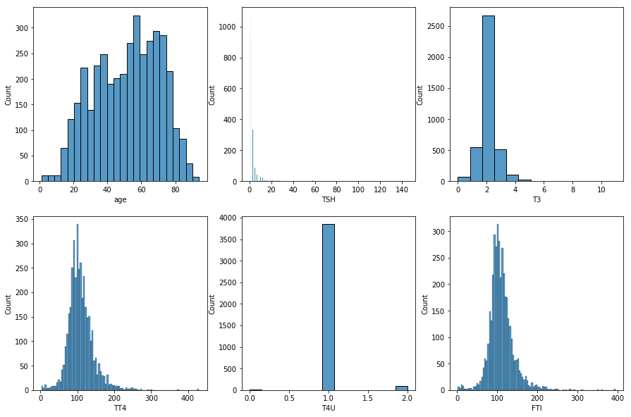

```python
# Create histograms
cols = ['age','TSH','T3','TT4','T4U','FTI']

plt.figure(figsize=(15,10),facecolor='white')
plotnumber = 1

for col in cols:
    ax = plt.subplot(2,3,plotnumber)
    sns.histplot(df2[col])
    plt.xlabel(col, fontsize=10)
    plotnumber+=1
```

> Observations:

> ```
> - Removing outlier from `age` has significantly improved the distribution and it looks normal.
> - Removing outlier from `TSH` has also improved the distribution a little but it is still heavilty skewed to the right.
> - Similarly, other features also seem to be skewed to the right.
> ```

Let's apply some transforations to the data to see if the data can be normally distributed.

### Data Transformation

Apply some transforations to the data to see if the data can be normally distributed.

#### Apply log transformation

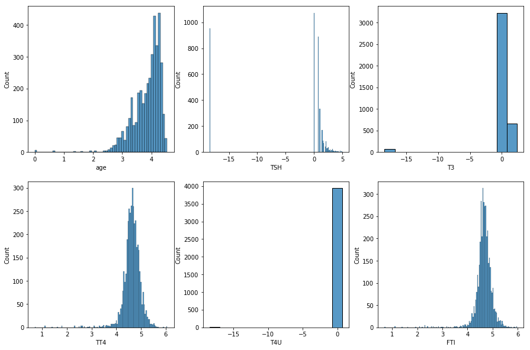

```python
# Create histograms
cols = ['age','TSH','T3','TT4','T4U','FTI']

plt.figure(figsize=(15,10),facecolor='white')
plotnumber = 1

for col in cols:
    ax = plt.subplot(2,3,plotnumber)
    sns.histplot(np.log(df2[col]+1e-8))
    plt.xlabel(col, fontsize=10)
    plotnumber+=1
```

> The data seems to be skewed to the left after applyting log transformation.

#### Apply Box-cox tranformation

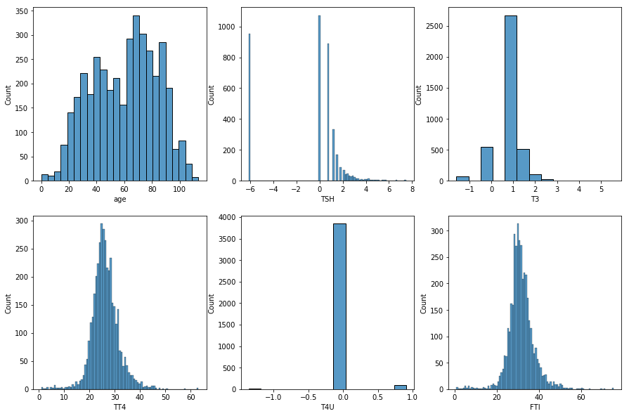

```python
# Create histograms
cols = ['age','TSH','T3','TT4','T4U','FTI']

plt.figure(figsize=(15,10),facecolor='white')
plotnumber = 1
param=[]
for col in cols:
    ax = plt.subplot(2,3,plotnumber)
    col_bx,p = stats.boxcox(df2[col]+1e-8)
    sns.histplot(col_bx)
    param.append(p)
    plt.xlabel(col, fontsize=10)
    plotnumber+=1
```

```python
# Transformation parameters for eahc feature
param
```

```
[1.0550222277705679,
 0.1537593101418859,
 0.62709777401318,
 0.6048130750519881,
 0.7376933654702804,
 0.656094585046508]
```

### Distribution of `Class`

In this section, we will check the distribution of our dependent variable `Class`. We will aso use oversampling technqiue to handle imbalanced class.

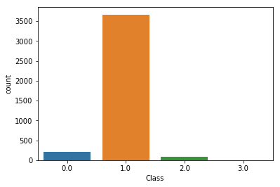

```python
# Check distribution of cateogircal `Class` feature
sns.countplot(x='Class', data=df2);
```

> The data is highly imbalanced with majority of data represented by Class = 1.

Let's oversample the data.

#### Oversample using `RandomOverSampler()`

```python
x = df2.drop(['Class'], axis=1)
y = df2['Class']

sampler = RandomOverSampler()
x_sampled, y_sampled = sampler.fit_resample(x,y)
```

```python
# Check shape
x_sampled.shape
```

```
(14664, 25)
```

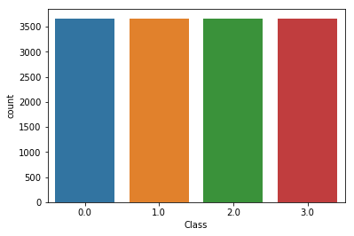

```python
# Check data for each category
sns.countplot(y_sampled);
```

```python
# Create df
x_sampled = pd.DataFrame(x_sampled, columns=x.columns)
x_sampled.head()
```

|  | age | sex | on_thyroxine | query_on_thyroxine | on_antithyroid_medication | sick | pregnant | thyroid_surgery | I131_treatment | query_hypothyroid | query_hyperthyroid | lithium | goitre | tumor | hypopituitary | psych | TSH | T3 | TT4 | T4U | FTI | referral_source_SVHC | referral_source_SVHD | referral_source_SVI | referral_source_other |
| --- | --- | --- | --- | --- | --- | --- | --- | --- | --- | --- | --- | --- | --- | --- | --- | --- | --- | --- | --- | --- | --- | --- | --- | --- | --- |
| 0 | 49.0 | 0.0 | 0.0 | 0.0 | 0.0 | 1.0 | 0.0 | 0.0 | 0.0 | 0.0 | 0.0 | 0.0 | 0.0 | 0.0 | 0.0 | 0.0 | 1.0 | 2.0 | 93.0 | 1.0 | 99.0 | 0.0 | 0.0 | 0.0 | 1.0 |
| 1 | 46.0 | 1.0 | 0.0 | 0.0 | 0.0 | 0.0 | 0.0 | 0.0 | 0.0 | 0.0 | 0.0 | 0.0 | 0.0 | 0.0 | 0.0 | 1.0 | 1.0 | 3.0 | 125.0 | 1.0 | 122.0 | 1.0 | 0.0 | 0.0 | 0.0 |
| 2 | 80.0 | 0.0 | 0.0 | 0.0 | 1.0 | 0.0 | 0.0 | 0.0 | 0.0 | 0.0 | 0.0 | 0.0 | 0.0 | 0.0 | 0.0 | 0.0 | 2.0 | 2.0 | 83.0 | 1.0 | 76.0 | 0.0 | 0.0 | 0.0 | 1.0 |
| 3 | 80.0 | 0.0 | 0.0 | 0.0 | 0.0 | 0.0 | 0.0 | 0.0 | 0.0 | 0.0 | 0.0 | 0.0 | 0.0 | 0.0 | 0.0 | 1.0 | 1.0 | 2.0 | 94.0 | 1.0 | 100.0 | 1.0 | 0.0 | 0.0 | 0.0 |
| 4 | 26.0 | 0.0 | 0.0 | 0.0 | 0.0 | 0.0 | 0.0 | 0.0 | 0.0 | 0.0 | 0.0 | 0.0 | 0.0 | 0.0 | 0.0 | 0.0 | 2.0 | 3.0 | 108.0 | 1.0 | 90.0 | 0.0 | 0.0 | 0.0 | 1.0 |

## Clustering

Here, we determine the best number of clusters in which the data can be split into.

```python
wcss = []
for i in range(1,10):
    kmeans = KMeans(n_clusters=i, init='k-means++', random_state=42)
    pred = kmeans.fit(x_sampled)
    wcss.append(pred.inertia_)
```

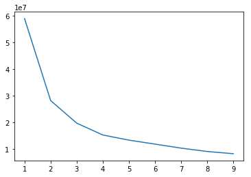

```python
plt.plot(range(1,10), wcss)
```

```python
kmeans = KMeans(n_clusters=i, init='k-means++', random_state=42)
pred = kmeans.fit(x_sampled)
```

## Modeling

This section shows 2/4 modelling techniques used to model the training data. Refer to the application for full details on various models and hypter-parameter tuning performed.

```python
tdf = pd.read_csv('test_cluster')
tdf.shape
```

```
(6127, 28)
```

```python
tdf.drop(['Cluster','Unnamed: 0'], inplace=True, axis=1)
```

```python
tdf.columns
```

```
Index(['age', 'sex', 'on_thyroxine', 'query_on_thyroxine', 'on_antithyroid_medication', 'sick', 'pregnant', 'thyroid_surgery', 'I131_treatment', 'query_hypothyroid', 'query_hyperthyroid', 'lithium', 'goitre', 'tumor', 'hypopituitary', 'psych', 'TSH', 'T3', 'TT4', 'T4U', 'FTI', 'referral_source_SVHC'…
```

```python
X = tdf.drop('Label', axis=1)
Y = tdf['Label']
x_train, x_test, y_train, y_test = train_test_split(X, Y,
                                                    test_size=1/3, random_state=101)
```

```python
y_train.shape
```

```
(4084,)
```

```python
from xgboost import XGBClassifier
from sklearn.model_selection import train_test_split, GridSearchCV
from sklearn.metrics import roc_auc_score
```

### XGB

```python
%%time
xgb = XGBClassifier(objective='multi:softmax')
param_grid = {'learning_rate': [0.5, 0.1, 0.01, 0.001],
              'max_depth': [3, 5, 10, 20],
              'n_estimators': [10, 50, 100, 200]}

grid_search = GridSearchCV(estimator=xgb, param_grid=param_grid,
                           cv=5, verbose=3)
grid_search.fit(x_train, y_train)
```

[output not shown]

[output not shown]

[output not shown]

[output not shown]

[output not shown]

[output not shown]

[output not shown]

[output not shown]

[output not shown]

[output not shown]

[output not shown]

[output not shown]

[output not shown]

[output not shown]

[output not shown]

[output not shown]

[output not shown]

[output not shown]

[output not shown]

[output not shown]

[output not shown]

[output not shown]

[output not shown]

[output not shown]

[output not shown]

[output not shown]

[output not shown]

[output not shown]

[output not shown]

[output not shown]

[output not shown]

[output not shown]

[output not shown]

[output not shown]

[output not shown]

[output not shown]

[output not shown]

[output not shown]

[output not shown]

[output not shown]

[output not shown]

[output not shown]

[output not shown]

[output not shown]

[output not shown]

[output not shown]

[output not shown]

[output not shown]

[output not shown]

[output not shown]

[output not shown]

[output not shown]

[output not shown]

[output not shown]

[output not shown]

[output not shown]

[output not shown]

[output not shown]

[output not shown]

[output not shown]

[output not shown]

[output not shown]

[output not shown]

[output not shown]

[output not shown]

[output not shown]

[output not shown]

[output not shown]

[output not shown]

[output not shown]

[output not shown]

[output not shown]

[output not shown]

[output not shown]

[output not shown]

[output not shown]

[output not shown]

[output not shown]

[output not shown]

[output not shown]

[output not shown]

[output not shown]

[output not shown]

[output not shown]

[output not shown]

[output not shown]

[output not shown]

[output not shown]

[output not shown]

[output not shown]

[output not shown]

[output not shown]

[output not shown]

[output not shown]

[output not shown]

[output not shown]

[output not shown]

[output not shown]

[output not shown]

[output not shown]

[output not shown]

[output not shown]

[output not shown]

[output not shown]

[output not shown]

[output not shown]

[output not shown]

[output not shown]

[output not shown]

[output not shown]

[output not shown]

[output not shown]

[output not shown]

[output not shown]

[output not shown]

[output not shown]

[output not shown]

[output not shown]

[output not shown]

[output not shown]

[output not shown]

[output not shown]

[output not shown]

[output not shown]

[output not shown]

[output not shown]

[output not shown]

[output not shown]

[output not shown]

[output not shown]

[output not shown]

[output not shown]

[output not shown]

[output not shown]

[output not shown]

[output not shown]

[output not shown]

[output not shown]

[output not shown]

[output not shown]

[output not shown]

[output not shown]

[output not shown]

[output not shown]

[output not shown]

[output not shown]

[output not shown]

[output not shown]

[output not shown]

[output not shown]

[output not shown]

[output not shown]

[output not shown]

[output not shown]

[output not shown]

[output not shown]

[output not shown]

[output not shown]

[output not shown]

[output not shown]

[output not shown]

[output not shown]

[output not shown]

[output not shown]

[output not shown]

[output not shown]

[output not shown]

[output not shown]

[output not shown]

[output not shown]

[output not shown]

[output not shown]

[output not shown]

[output not shown]

[output not shown]

[output not shown]

[output not shown]

[output not shown]

[output not shown]

[output not shown]

[output not shown]

[output not shown]

[output not shown]

[output not shown]

[output not shown]

[output not shown]

[output not shown]

[output not shown]

[output not shown]

[output not shown]

[output not shown]

[output not shown]

[output not shown]

[output not shown]

[output not shown]

[output not shown]

[output not shown]

[output not shown]

```
CPU times: user 15min 33s, sys: 15.8 s, total: 15min 49s
Wall time: 1min 24s
```

```
GridSearchCV(cv=5,
             estimator=XGBClassifier(base_score=None, booster=None,
                                     colsample_bylevel=None,
                                     colsample_bynode=None,
                                     colsample_bytree=None, gamma=None,
                                     gpu_id=None, importance_type='gain',
                                     interaction_constraints=None,
                                     learning_rate=None, max_delta_step=None,
                                     max_depth=None, min_child_weight=None,
                                     missing=nan, monotone_constraints=None,
                                     n_estimators=100, n_jobs=None,
                                     num_parallel_tree=None,
                                     objective='multi:softmax',
                                     random_state=None, reg_alpha=None,
                                     reg_lambda=None, scale_pos_weight=None,
                                     subsample=None, tree_method=None,
                                     validate_parameters=None, verbosity=None),
             param_grid={'learning_rate': [0.5, 0.1, 0.01, 0.001],
                         'max_depth': [3, 5, 10, 20],
                         'n_estimators': [10, 50, 100, 200]},
             verbose=3)
```

```python
grid_search.best_params_
```

```
{'learning_rate': 0.1, 'max_depth': 10, 'n_estimators': 200}
```

```python
xgb_model = XGBClassifier(max_depth=10, learning_rate=0.1,
                          n_estimators=200)
xgb_model.fit(x_train, y_train)
```

[output not shown]

```
XGBClassifier(base_score=0.5, booster='gbtree', colsample_bylevel=1,
              colsample_bynode=1, colsample_bytree=1, gamma=0, gpu_id=-1,
              importance_type='gain', interaction_constraints='',
              learning_rate=0.1, max_delta_step=0, max_depth=10,
              min_child_weight=1, missing=nan, monotone_constraints='()',
              n_estimators=200, n_jobs=12, num_parallel_tree=1,
              objective='multi:softprob', random_state=0, reg_alpha=0,
              reg_lambda=1, scale_pos_weight=None, subsample=1,
              tree_method='exact', validate_parameters=1, verbosity=None)
```

```python
pred_xgb = xgb_model.predict_proba(x_test)
roc_auc_score(y_test, pred_xgb, multi_class='ovr')
```

```
0.9999967572787911
```

### SVM

```python
from sklearn.svm import SVC
```

```python
svc = SVC(kernel='rbf', probability=True)
param_grid = {'C': [0.1,1, 10], 'gamma': [0.1,0.01,0.001]}
# param_grid = {'C': [0.1], 'gamma': [0.1],'kernel': ['rbf', 'poly']}
grid_search = GridSearchCV(estimator=svc, param_grid=param_grid,
                           cv=5, verbose=3)
grid_search.fit(x_train, y_train)
```

```
Fitting 5 folds for each of 9 candidates, totalling 45 fits
[CV 1/5] END ..................C=0.1, gamma=0.1;, score=0.869 total time=   4.2s
[CV 2/5] END ..................C=0.1, gamma=0.1;, score=0.849 total time=   4.1s
[CV 3/5] END ..................C=0.1, gamma=0.1;, score=0.846 total time=   4.0s
[CV 4/5] END ..................C=0.1, gamma=0.1;, score=0.865 total time=   4.2s
[CV 5/5] END ..................C=0.1, gamma=0.1;, score=0.884 total time=   4.2s
[CV 1/5] END .................C=0.1, gamma=0.01;, score=0.971 total time=   2.8s
[CV 2/5] END .................C=0.1, gamma=0.01;, score=0.977 total time=   2.9s
[CV 3/5] END .................C=0.1, gamma=0.01;, score=0.977 total time=   2.7s
[CV 4/5] END .................C=0.1, gamma=0.01;, score=0.976 total time=   2.7s
[CV 5/5] END .................C=0.1, gamma=0.01;, score=0.982 total time=   2.9s
[CV 1/5] END ................C=0.1, gamma=0.001;, score=0.955 total time=   2.0s
[CV 2/5] END ................C=0.1, gamma=0.001;, score=0.957 total time=   1.9s
[CV 3/5] END ................C=0.1, gamma=0.001;, score=0.963 total time=   1.8s
[CV 4/5] END ................C=0.1, gamma=0.001;, score=0.944 total time=   1.8s
[CV 5/5] END ................C=0.1, gamma=0.001;, score=0.962 total time=   1.8s
[CV 1/5] END ....................C=1, gamma=0.1;, score=1.000 total time=   3.0s
[CV 2/5] END ....................C=1, gamma=0.1;, score=1.000 total time=   3.0s
[CV 3/5] END ....................C=1, gamma=0.1;, score=1.000 total time=   3.0s
[CV 4/5] END ....................C=1, gamma=0.1;, score=1.000 total time=   3.0s
[CV 5/5] END ....................C=1, gamma=0.1;, score=1.000 total time=   3.0s
[CV 1/5] END ...................C=1, gamma=0.01;, score=0.993 total time=   1.5s
[CV 2/5] END ...................C=1, gamma=0.01;, score=0.996 total time=   1.5s
[CV 3/5] END ...................C=1, gamma=0.01;, score=0.982 total time=   1.4s
[CV 4/5] END ...................C=1, gamma=0.01;, score=0.989 total time=   1.4s
[CV 5/5] END ...................C=1, gamma=0.01;, score=0.979 total time=   1.5s
[CV 1/5] END ..................C=1, gamma=0.001;, score=0.972 total time=   0.9s
[CV 2/5] END ..................C=1, gamma=0.001;, score=0.976 total time=   0.9s
[CV 3/5] END ..................C=1, gamma=0.001;, score=0.972 total time=   0.9s
[CV 4/5] END ..................C=1, gamma=0.001;, score=0.966 total time=   0.8s
[CV 5/5] END ..................C=1, gamma=0.001;, score=0.971 total time=   0.9s
[CV 1/5] END ...................C=10, gamma=0.1;, score=1.000 total time=   2.8s
[CV 2/5] END ...................C=10, gamma=0.1;, score=1.000 total time=   3.2s
[CV 3/5] END ...................C=10, gamma=0.1;, score=1.000 total time=   2.9s
[CV 4/5] END ...................C=10, gamma=0.1;, score=1.000 total time=   2.8s
[CV 5/5] END ...................C=10, gamma=0.1;, score=1.000 total time=   2.8s
[CV 1/5] END ..................C=10, gamma=0.01;, score=0.991 total time=   1.2s
[CV 2/5] END ..................C=10, gamma=0.01;, score=0.998 total time=   1.2s
[CV 3/5] END ..................C=10, gamma=0.01;, score=0.990 total time=   1.2s
[CV 4/5] END ..................C=10, gamma=0.01;, score=0.991 total time=   1.2s
[CV 5/5] END ..................C=10, gamma=0.01;, score=0.993 total time=   1.2s
[CV 1/5] END .................C=10, gamma=0.001;, score=0.979 total time=   0.5s
[CV 2/5] END .................C=10, gamma=0.001;, score=0.988 total time=   0.5s
[CV 3/5] END .................C=10, gamma=0.001;, score=0.978 total time=   0.5s
[CV 4/5] END .................C=10, gamma=0.001;, score=0.973 total time=   0.5s
[CV 5/5] END .................C=10, gamma=0.001;, score=0.973 total time=   0.5s
```

```
GridSearchCV(cv=5, estimator=SVC(probability=True),
             param_grid={'C': [0.1, 1, 10], 'gamma': [0.1, 0.01, 0.001]},
             verbose=3)
```

```python
grid_search.best_params_
```

```
{'C': 1, 'gamma': 0.1}
```

```python
svm_model = SVC(kernel='rbf', probability=True,
                C=1, gamma=0.1)
svm_model.fit(x_train, y_train)
```

```
SVC(C=1, gamma=0.1, probability=True)
```

```python
pred_svm = svm_model.predict_proba(x_test)
roc_auc_score(y_test, pred_svm, multi_class='ovr')
```

```
1.0
```

-- End of Exploration --